# lab

**Convex and Distributed Optimization Lab**  
**MSIAM — Université Grenoble Alpes — 2019/2020**  
**Lecturers: Jérôme Malick, Yassine Laguel, Sélim Chraibi**

**Author(s): Kotova Margarita, Rodina Sofia, Ermolova Marina**

```python
# Automatic reload of local libraries
%load_ext autoreload
%autoreload 2
%reload_ext autoreload
%matplotlib inline
```

> **I. Introduction**  
> **II. The optimization problem**  
> **III. Implementing the solvers**  
> GD (Gradient descent))  
> SGD (Stochastic Gradient Descent))  
> SAGA (Stochastic Average Gradient "Amélioré"))  
> SVRG (Stochastic Variance Reduced Gradient))  
> Comparison  
> **IV. Regularization**  
> **V. Further development**

In this lab, you will implement optimization algorithms that you've studied in class and use them to fit a logistic regression classification model.

You will be implementing a simplified version of [`sklearn.linear_model.LogisticRegression`](https://scikit-learn.org/stable/modules/generated/sklearn.linear_model.LogisticRegression.html).

Part of the work has already been done for you (see the `\lib` folder), so you'll only have to implement the `##### TODO (i) #####` sections of the code. Whenever you complete such a section, we ask you to **copy it in this notebook**. We want you to **only send us a pdf or html export of this notebook** so we won't be able to see your work if it's not in this notebook.

Report in groups of 1 to 3 students.  
**Due date:** Monday, January 6, 2019 (before midnight).  
**Send to:** cdo.grenoble@gmail.com

# I. Introduction

We consider the [Student Performance](http://archive.ics.uci.edu/ml/datasets/Student+Performance) dataset. This dataset contains student demographic, social, school-related features, how many classes they've missed, etc.

The goal we give ourselves is to predict whether a student will pass (final grade > 12).

We denote $A \in \mathcal{M}_{n,d}(\mathbb{R})$ the feature matrix, containing $n$ samples with $d$ features, and $b \in \{-1,1\}^n$ the label vector where $-1$ encodes `fail` and $1$ encodes `pass`.

The data has already been preprocessed (yay less work for you 🎉). You can check `\lib\datasets.py` if you're curious, otherwise, you can just use the following to load your dataset:

```python
from lib.datasets import load_student_data

A_train, A_test, b_train, b_test = load_student_data('data/student-mat.csv', split=0.25)
```

As mentioned previously, you're going to implement a simplified version of [`sklearn.linear_model.LogisticRegression`](https://scikit-learn.org/stable/modules/generated/sklearn.linear_model.LogisticRegression.html). So let's first see what the finished product should look like.

**Question:**

- Import [sklearn.linear_model.LogisticRegression](https://scikit-learn.org/stable/modules/generated/sklearn.linear_model.LogisticRegression.html) .
- Create an instance of sklearn's logistic regression classifiers with SAGA as its solver.
- Fit the classifier on the training data and compute the score of the fitted model on the test set.

```python
from sklearn.linear_model import LogisticRegression
from sklearn.metrics import accuracy_score

acc = 0
for rs in range(0, 100, 10):
    clf = LogisticRegression(random_state=rs, solver='saga', max_iter=400).fit(A_train, b_train)
    b_predicted = clf.predict(A_test)
    acc += accuracy_score(b_test, b_predicted)
acc /= 10
print("Accuracy of sklearn LogisticRegression:", acc)
```

```
Accuracy of sklearn LogisticRegression: 0.9393939393939394
```

# II. The optimization problem

Logistic regression consists in finding the parameter $x \in \mathbb{R}^d$ that best fits: $$ b_i = \begin{cases} \phantom{-}1 \ \textrm{ if }\ \langle a_{i}, x\rangle \ge 0 \\ -1 \ \textrm{ if }\ \langle a_{i}, x\rangle < 0 \end{cases} $$ for all the samples $i$ of the training set (where $a_i$ is the $i^{th}$ line of $A$ and $b_i$ the $i^{th}$ element of $b$). To measure this fit, logistic regression chooses the following loss:

$$ \textrm{LogisticLoss}(b_i, \left\langle a_{i}, x\right\rangle ) = \log \left(1+\exp \left(-b_{i}\left\langle a_{i}, x\right\rangle\right)\right) $$

The corresponding optimization problem we will consider is the following:

Minimization of the empirical risk $f$ of the $L_2$-regularized logistic regression model, on the dataset $(A_{\textrm{train}},b_{\textrm{train}})$: $$ \begin{aligned} \textrm{min}_{x\in \mathbb{R}^d} \ f(x) \ &= \ \textrm{min}_{x\in \mathbb{R}^d} \ \frac{1}{n_{\textrm{train}}} \sum_{i=1}^{n_{\textrm{train}}} f_i(x) \\ &= \ \textrm{min}_{x\in \mathbb{R}^d}\frac{1}{n_{\textrm{train}}} \sum_{i=1}^{n_{\textrm{train}}} \textrm{LogisticLoss}(b_i, \left\langle a_{i}, x\right\rangle ) + \frac{l_2}{2}\|x\|^{2}_2, \end{aligned} $$ where $l_2 \ge 0$ is the $L_2$ regularization coefficient.

To simplify the notation, we'll stop indexing $A$, $b$ and $n$ with "$\textrm{train}$" in the following.

**Question:** $f$ is $\mu$-strongly convex.

- Give a lower bound on $\mu$.
- Complete **TODO (1)** in **\lib\linear_model.py**.

> **Answer:** A function $f$ is strongly convex with parameter $\mu$ if and only if the function $f(x)-\frac{\mu}{2}||x||^2$ is convex.

> $\log \left(1+\exp \left(-b_{i}\left\langle a_{i}, x\right\rangle\right)\right)$ is a convex function (exponent and log are convex)

> $\frac{1}{n_{\textrm{train}}} \sum_{i=1}^{n_{\textrm{train}}} \textrm{LogisticLoss}(b_i, \left\langle a_{i}, x\right\rangle)$ is convex, because sum and min of convex functions are convex.

> Consequently, $f(x)-\frac{\mu}{2}||x||^2 = \frac{1}{n_{\textrm{train}}} \sum_{i=1}^{n_{\textrm{train}}} \textrm{LogisticLoss}(b_i, \left\langle a_{i}, x\right\rangle) + \frac{l_2}{2}\|x\|^{2}_2 -\frac{\mu}{2}||x||^2$ is convex, if $\mu$ is not less than $l_2$.

> $\mu = l_2$

**Question:** For any square matrix $M$, denote $\lambda_{\max}(M)$ the largest eighenvalue of $M$.

- Prove that $\lambda_{\max}(\nabla^2 f_i) \le \lambda_{\max}(\frac{a_i a_i^T}{4} + l_2 I_d)$
- Prove that $\lambda_{\max}(a_i a_i^T) \le \|a_i\|^2_2$

> **Answer:**

> > \begin{equation} \frac{\partial f_i(x)}{\partial x} =\frac{\partial}{\partial x} \log\big[ 1 + \exp \left\{ -b_{i}\left\langle a_{i}, x\right\rangle \right\} \big] + \frac{l_2}{2} \| x \|^2 = \frac{ \exp \left\{ -b_{i}\left\langle a_{i}, x\right\rangle \right\} }{ 1 + \exp \left\{ -b_{i}\left\langle a_{i}, x\right\rangle \right\} } ( -b_i a_i ) + l_2 x = \frac{-b_i a_i }{1 + \exp \left\{ b_{i}\left\langle a_{i}, x\right\rangle \right\}} + l_2 x. \end{equation}\begin{equation} \nabla^2 f_i = \frac{\exp \left\{ b_{i}\left\langle a_{i}, x\right\rangle \right\}}{\Big[ 1 + \exp \left\{ b_{i}\left\langle a_{i}, x\right\rangle \right\} \Big]^2 } \Big[ -b_i^2 a_i a_i^T \Big] + l_2 I. \end{equation}

> > Let $\exp \left\{ b_{i}\left\langle a_{i}, x\right\rangle \right\} = m$, then $ \frac{\exp \left\{ b_{i}\left\langle a_{i}, x\right\rangle \right\}}{\Big[ 1 + \exp \left\{ b_{i}\left\langle a_{i}, x\right\rangle \right\} \Big]^2} = \frac{m}{(1+m)^2} = g(m)$

> > Let find maximum of g(m): $ \frac{d\;g(m)}{d\;m} = \frac{1 - m^2}{(1 + m)^4} \Rightarrow m = 1,\; g_{\max} = \frac{1}{4}.$

> > $\lambda_{\max}(\nabla^2 f_i) = \lambda_{\max} \left( \frac{\exp \left\{ b_{i}\left\langle a_{i}, x\right\rangle \right\}}{\Big[ 1 + \exp \left\{ b_{i}\left\langle a_{i}, x\right\rangle \right\} \Big]^2 } \Big[ -b_i^2 a_i a_i^T \Big] + l_2 I \right) \leq \lambda_\max \left[ \frac{a_i a_i^T}{4} + l_2 I \right] $

$M=A^{T} A$ is a square of a spectral norm $\| A \|_2 = \sup\limits_{\| x \|_2 = 1} \| A x \|$

> > Using the sub-multiplicativity of Frobenius norm $\| A x \|_2 \leq \| A \|_F \| x \|_2 = \sqrt{ \sum_{i, j = 1}^{n} A^2_{ij}} \cdot \| x \|_2$

> > Then $ \| a_i a_i^T \|_F = \sqrt{\sum\limits_{k, j = 1 \\ k = j}^n a^4_k + 2 \sum\limits_{k, j = 1 \\ k \neq j}^n a^2_k a^2_j } = \sqrt{\left(\sum\limits_{k = 1}^n a_k^2 \right)^2 } = \Big|\sum\limits_{k = 1}^n a_k^2\Big| = \| a \|^2_2$

A consequence of these results is that the $f_i$s and $f$ are all $L$-smooth with $L \le \frac{\max_i\|a_i\|^2_2}{4} + l_2$ and we can therefore use the following value in our implementation:

```
L = 0.25 * max(np.linalg.norm(A,2,axis=1))**2 + self.l2
```

# III. Implementing the solvers

To implement gradient methods, we need an oracle that will compute both batch gradients $\nabla f$ and partial gradients $\nabla f_i$.

**Question:** In the code below, $\nabla f$ has already been implemented.

- Complete **TODO (2)** bellow.
- Add your code to **\lib\linear_model.py**.

```
def grad(x, i=None):
    '''
    Gradient of the objective function at x.
    If no i is given, grad should return the batch gradient.
    Otherwise, it should return the partial gradient associated the the datapoint (A[i], b[i]).
    '''

    if i is None: # return batch gradient
        output = -b/(1 + np.exp(b*np.dot(A, x)))
        output = sum(np.diag(output))/n @ A
        output += self.l2*x
    else: # return partial gradient associated the datapoint (A[i], b[i])
        output = -b[i] / (1 + np.exp(b[i] * np.dot(A[i], x)))
        output = output * A[i]
        output += self.l2 * x
        pass
    return output
```

# GD (Gradient descent)

At iteration k of the GD algorithm, the following update is executed:

$$ x_{k+1} \leftarrow x_{k} - \gamma\nabla f(x_k) $$

**Question:**

- What stepsize $\gamma$ ensures the convergence of this algorithm and under what assumptions?
- Complete **TODO (3)** and **TODO (4)**
- Add your code to **\lib\solvers.py**.

> **Answer:** 𝑓 is $\mu$-strongly convex and L-smooth

> optimal stepsize $\gamma = \frac{2}{L+\mu}$

```
def GD(x0, grad, max_iter, n, L, mu):
    '''
    Parameters
    ----------
    x0: array, shape (nb_features,)
        Initialisation of the solver
    grad: function
        Gradient of the objective function
    max_iter: int
        Number of iterations (i.e. number of descent steps). Note that for GD or SVRG,
        one iteration is one epoch i.e, one pass through the data, while for SGD, SAG and SAGA,
        one iteration uses only one data point.
    n: int
        Dataset size
    L: float
        Smoothness constant of the objective function
    mu: float
        Strong convexity constant of the objective function

    Returns
    -------
    x: array, shape (nb_features,)
        final iterate of the solver
    x_tab: array, shape (nb_features, max_iter)
        table of all the iterates
    '''
    stepsize  = 2/(mu+L)
    x         = x0
    x_tab     = np.copy(x)

    for k in range(max_iter):
        x     =  x - stepsize*grad(x)
        x_tab = np.vstack((x_tab, x))

    return x, x_tab
```

**Question:** Run the code below to test your code.

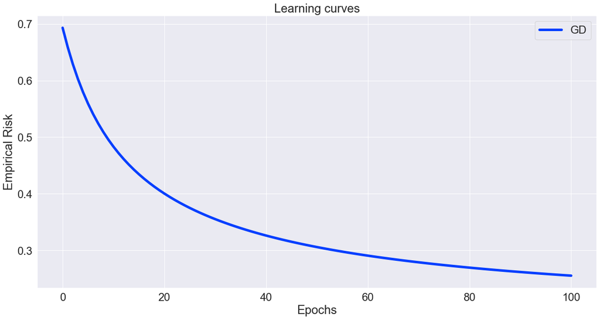

```python
from lib.linear_model import LogisticRegression
from lib.visuals import learning_curve

clf_gd = LogisticRegression(solver='gd', l2=0.01, max_iter=100)
clf_gd.fit(A_train, b_train)

learning_curve(GD=clf_gd)
```

# SGD (Stochastic Gradient Descent)

At iteration k of the SGD algorithm, the following update is executed:

$$ \begin{cases} i \textrm{ chosen randomly in } \{1...n\}\\ x_{k+1} \leftarrow x_{k} - \gamma_k \nabla f_i(x_k) \\ \end{cases} $$

**Question:**

- What stepsize $\gamma_k$ ensures the convergence of this algorithm and under what assumptions?
- Complete **TODO (5)**
- Add your code to **\lib\solvers.py**.

> **Answer:**
> - Let's take the Lipschitz constant L of gradient of function $f$ as optimal stepsize $\gamma=\frac{1}{L}$.

```
def SGD(x0, grad, max_iter, n, L, mu):
    step_size = 1/L
    x = x0
    x_tab = np.copy(x)

    for k in range(max_iter):
        i = np.random.randint(0, n)
        x = x - step_size * grad(x, i)

        if k%n == 0: # each completed epoch
            x_tab = np.vstack((x_tab, x))

    return x, x_tab
```

**Question:** Run the code below to test your code.

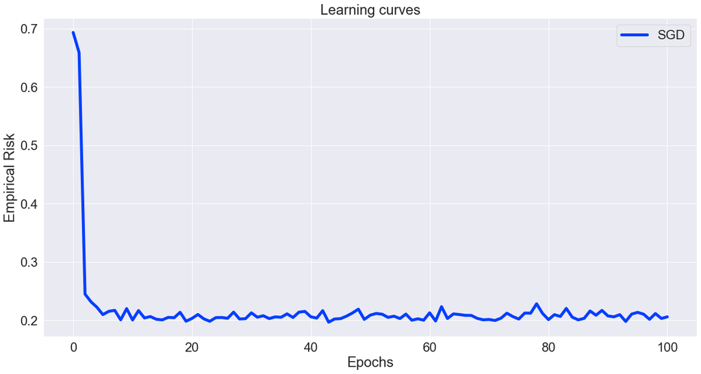

```python
clf_sgd = LogisticRegression(solver='sgd', l2=0.01, max_iter=100*len(b_train))
clf_sgd.fit(A_train, b_train)

learning_curve(SGD=clf_sgd)
```

# SAGA (Stochastic Average Gradient "Amélioré")

SAGA starts by computing a single batch gradient, then at iteration k, the following update is executed:

$$ \begin{cases} i \textrm{ chosen randomly in } \{1...n\}\\ x_{k+1} \leftarrow x_{k} - \gamma_k\big(\nabla f_i(x_k) - \alpha_i + \bar{\alpha}\big) \\ \alpha_i \leftarrow \nabla f_i(x) \end{cases} $$

where $(\alpha_j)_{j=1}^n$ are gradients evaluated at previous iterates and $\bar{\alpha}=\frac{1}{n}\sum^n_{j=1}\alpha_j$.

**Question:**

- What stepsize $\gamma_k$ ensures the convergence of this algorithm and under what assumptions?
- Complete **TODO (6)**
- Add your code to **\lib\solvers.py**.

> **Answer:** SAGA converges exponentially, if $\gamma = \frac{1}{2 (\mu m + L)}$ ($m$ is number of previous iterations) and $f_i$ is $L$-smooth and $\mu$-strongly convex.

```
def SAGA(x0, grad, max_iter, n, L, mu):
    grad_history = []
    step_size = 2/(mu+L)
    x = x0
    x_tab = np.copy(x)

    for k in range(max_iter):
        i = np.random.randint(0, n)
        grad_xi=grad(x, i)
        if len(grad_history)>0:
            x = x - step_size* (grad_xi - grad_history[-1] + np.mean(grad_history, axis=0))

        grad_history.append(grad_xi)
        step_size = 1 / (2*(mu * len(grad_history) + L))

        if k%n == 0: # each completed epoch
            x_tab = np.vstack((x_tab, x))

    return x, x_tab
```

**Question:** Run the code below to test your code.

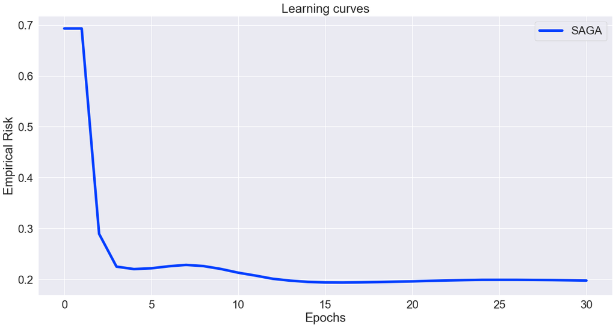

```python
clf_saga = LogisticRegression(solver='saga', l2=0.01, max_iter=30*len(b_train))
clf_saga.fit(A_train, b_train)

learning_curve(SAGA=clf_saga)
```

# SVRG (Stochastic Variance Reduced Gradient)

At iteration k of the SVRG algorithm, we perform the following:

$$ \begin{cases} \textrm{Compute the batch gradient } \nabla f(x_k)\\ \textrm{Initialise }y_0 = x_k\\ \textrm{for m in 0...M-1: } \begin{cases} i \textrm{ chosen randomly in } \{1...n\} \\ y_{m+1} \leftarrow y_{m} - \gamma_k\big(\nabla f_i(y_m) - \nabla f_i(x_k) + \nabla f(x_k)) \end{cases}\\ x_{k+1} \leftarrow y_{M} \end{cases} $$

**Question:**

- What stepsize $\gamma_k$ ensures the convergence of this algorithm and under what assumptions?
- Complete **TODO (7)**
- Add your code to **\lib\solvers.py**.

> **Answer**
> - $\gamma_{\mathrm{opt}} = \frac{2}{L+\mu}$, where $L$ is Lipshitz constant.

```
def SVRG(x0, grad, max_iter, n, L, mu):
    step_size = 2/(mu+L)
    x = x0
    x_tab = np.copy(x)
    M=10

    for k in range(max_iter):

        y=np.copy(x)

        for m in range(M):
            i = np.random.randint(0, n)
            y -= step_size * (grad(y, i) - grad(x, i) + grad(x))

        x=y


        x_tab = np.vstack((x_tab, x))

    return x, x_tab
```

**Question:** Run the code below to test your code.

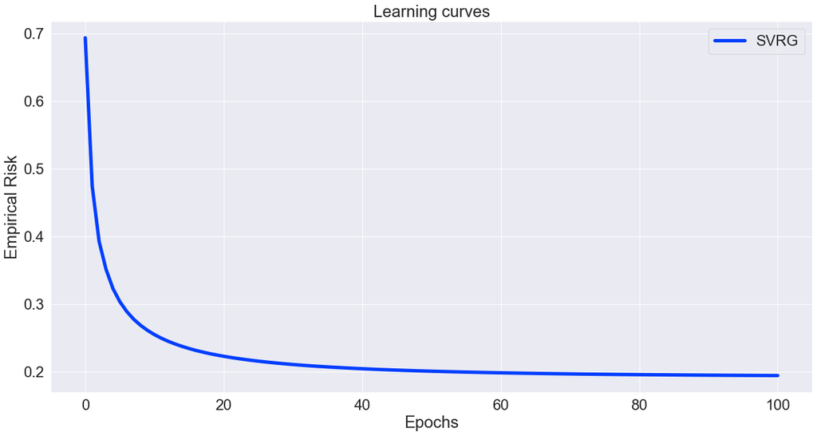

```python
clf_svrg = LogisticRegression(solver='svrg', l2=0.01, max_iter=100)
clf_svrg.fit(A_train, b_train)

learning_curve(SVRG=clf_svrg)
```

# Comparison

**Question:** Run the code below to compare all the methods you've implemented.

```python
epochs = 50
n = len(b_train)

clf_gd   = LogisticRegression(solver='gd', l2=0.01, max_iter=epochs)
clf_sgd  = LogisticRegression(solver='sgd', l2=0.01, max_iter=epochs*n)
clf_saga = LogisticRegression(solver='saga', l2=0.01, max_iter=epochs*n)
clf_svrg = LogisticRegression(solver='svrg', l2=0.01, max_iter=epochs)

clf_gd.fit(A_train, b_train)
clf_sgd.fit(A_train, b_train)
clf_saga.fit(A_train, b_train)
clf_svrg.fit(A_train, b_train)
```

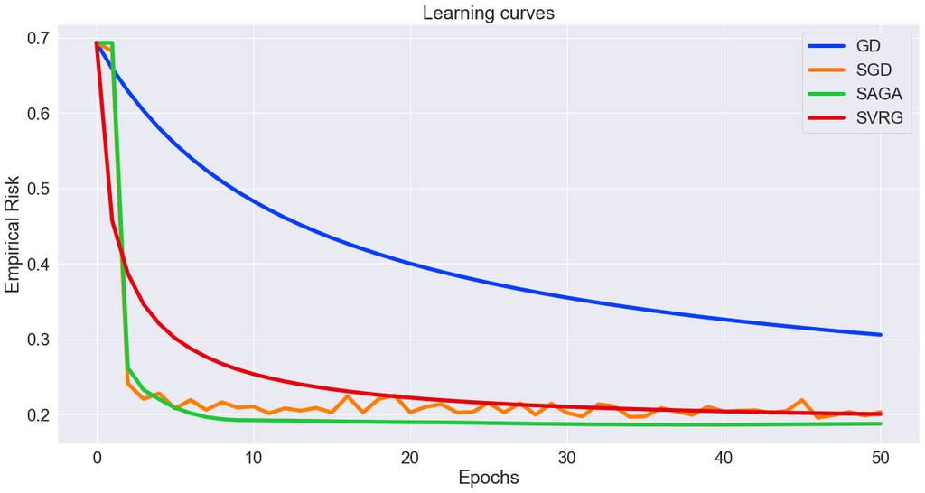

```
gd:	Accuracy on training set: 91.2%
	Accuracy on testing set:  88.9%
sgd:	Accuracy on training set: 92.9%
	Accuracy on testing set:  91.9%
saga:	Accuracy on training set: 94.3%
	Accuracy on testing set:  92.9%
svrg:	Accuracy on training set: 93.6%
	Accuracy on testing set:  90.9%
```

```python
learning_curve(GD=clf_gd, SGD=clf_sgd, SAGA=clf_saga, SVRG=clf_svrg)

for clf, name in zip([clf_gd, clf_sgd, clf_saga, clf_svrg], ['gd', 'sgd', 'saga', 'svrg']):
    print(name + ':' \
          + "\tAccuracy on training set: {0:0.1f}%".format(100*clf.score(A_train, b_train)))
    print("\tAccuracy on testing set:  {0:0.1f}%".format(100*clf.score(A_test, b_test)))
```

# IV. Regularization

**Question:**

- Rewrite the empirical risk minimization objective with both $L_1$ and $L_2$ regularization (with coefficients $l_1$ and $l_2$).
- Is this objective $\mu$-strongly convex, $L$-smooth, differentiable?
- Complete the **TODO (8)** to account for the new term in the objective.
- Add your code to **lib/linear_model.py**.

> **Answer:** The empirical risk minimization objective with both $L_1$ and $L_2$ regularization

$$ \begin{aligned} f_{new}(x) = f(x)+l_1\|x\|_1 &=\frac{1}{n_{\textrm{train}}} \sum_{i=1}^{n_{\textrm{train}}} \textrm{LogisticLoss}(b_i, \left\langle a_{i}, x\right\rangle ) + l_1\|x\|_1+ \frac{l_2}{2}\|x\|^{2}_2, \end{aligned} $$

```
self._empirical_risk = lambda x: sum(self._logistic_loss(A, b, x))/n \
                                 + self.l2/2.0 * np.linalg.norm(x,2)**2 \
                                 + self.l1 * np.linalg.norm(x,1)
```

This objective is:

- $\mu$-strongly convex as $\|x\|_1$ is convex, so $f(x)-\frac{\mu}{2}||x||^2+l_1\|x\|_1$ is also convex
- $L$-smooth as $\|x\|_1$ is $L$-smooth because it's a norm and $f(x)$ is $L$-smooth as we proved before.
- non-differentiable as $\|x\|_1$ is not differentiable

The minimization algorithms we've implemented have a slow rate of convergence for this new objective function. We will therefore use *proximal* variations of these algorithms.

**Question:** Using the $\textrm{prox}_{l_1 \|\cdot\|_1}$ operator, write down the $k^{th}$ step of proximal GD, proximal SGD, proximal SAGA, and proximal SVRG.

> **Answer:**
> - GD: $x_{k} = \textrm{prox}_{l_1 \|\cdot\|_1}\big(x_{k-1} - \gamma\nabla f(x_{k-1})\big)$
> - SGD: $x_{k} = \textrm{prox}_{l_1 \|\cdot\|_1}\big( x_{k-1} - \gamma_{k-1} \nabla f_i(x_{k-1}) \big)$
> - SAGA: $x_{k} = \textrm{prox}_{l_1 \|\cdot\|_1}\big( x_{k-1} - \gamma_{k-1}\big(\nabla f_i(x_{k-1}) - \alpha_i + \bar{\alpha} \big)$
> - SVRG: $x_{k} = \textrm{prox}_{l_1 \|\cdot\|_1}\big( y_{k-1} - \gamma_l\big(\nabla f_i(y_{k-1}) - \nabla f_i(x_l) + \nabla f(x_l)) \big)$

**Question:**

- Give a closed-form expression of $\textrm{prox}_{l_1 \|\cdot\|_1}$
- Complete **TODO (9)** (note that you can access the $l_1$ coefficient using **self.l1**).
- Add your code to **\lib\linear_model.py**.

> **Answer:**

The proximal operator is defined on Hilbert space $\mathcal{X}$ as

$\textrm{prox}_{f}(v)=\arg \min _{x \in \mathcal{X}}\left(f(x)+\frac{1}{2}\|x-v\|_{2}^{2}\right)$

In our case as this problem is separable w.r. to $v$ and $x$ $\textrm{prox}_{l_1 \|\cdot\|_1}(v)=\arg \min_{x}\left(l_1 \|x\|_1+\frac{1}{2}\|x-v\|_{2}^{2}\right)=\arg \min_{x}\left(l_1 |x_i|+\frac{1}{2}(x_i-v_i)^{2}\right)$

$\textrm{prox}_{l_1 \|\cdot\|_1}(v) = \arg \min _{x} \begin{cases} l_1 x_i+\frac{1}{2}(x_i-v_i)^{2} &\text{if $x_i > 0$}\\ -l_1 x_i+\frac{1}{2}(x_i-v_i)^{2} &\text{if $x_i < 0$}\\ \frac{1}{2}(x_i-v_i)^{2} &\text{if $x_i = 0$} \end{cases}$

We count the derivatives: $\begin{cases} l_1 +x_i-v_i = 0 &\text{if $x_i > 0$}\\ -l_1 +x_i-v_i = 0 &\text{if $x_i < 0$}\\ [-1, 1] &\text{if $x_i = 0$} \end{cases}$

So

$\begin{cases} x_i= v_i - l_1 &\text{if $x_i > 0$}\\ x_i= v_i + l_1 &\text{if $x_i < 0$}\\ x_i = 0 &\text{if $x_i = 0$} \end{cases}$

and

$\textrm{prox}_{l_1 \|\cdot\|_1}(v) = \mathrm{sign}\left(v_{i}\right) \max \left(\left|v_{i}\right|-l_1, 0\right)$

```
def prox(x, stepsize):
    return np.sign(x) * np.max(np.abs(x) - self.l1 * stepsize, 0)
```

**Question:**

- Add **prox** to the attributes of the solvers (both in the call to **self.solver** in **/lib/linear_model.py** and in **/lib/solvers.py**) as follows:  
  solver(x0, grad, **prox**, self.max_iter, n, L, mu)
- Add a proximal step to all the algorithms in **/lib/solvers.py**.
- Paste one of these algorithms in the cell bellow.

```
def SGD(x0, grad, prox, max_iter, n, L, mu):
    step_size = 1/(L)

    x = x0
    x_tab = np.copy(x)

    for k in range(max_iter):
        i = np.random.randint(0, n)
        x = x - step_size * grad(x, i)
        x = prox(x, step_size)

        if k%n == 0: # each completed epoch
            x_tab = np.vstack((x_tab, x))

    return x, x_tab
```

**Question:** If your proximal gradient descent is correctly implemented, the following cell will plot the support of the solution for various values of $l_1$.

- Interpret the plot and explain what can $L_1$ regularization be used for.

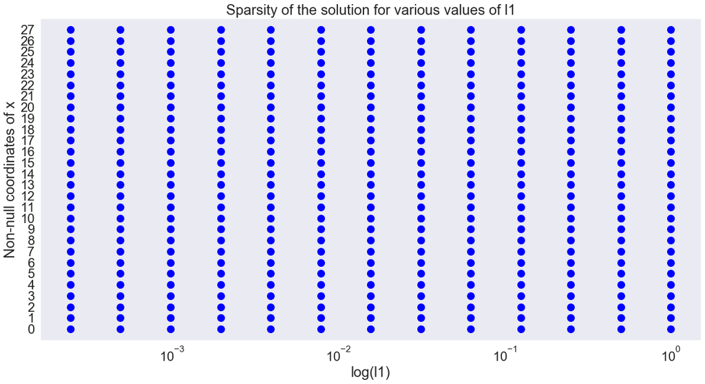

```python
from lib.visuals import l1_regularization_plot

clf = lambda l1: LogisticRegression(solver='gd', l1=l1, l2=0.1, max_iter=1000)

l1_regularization_plot(clf, A_train, b_train)
```

**Question:** The following cell will plot the value of the coordinates of the solution for various values of $l_2$.

- Interpret the plot and explain what can $L_2$ regularization be used for.

> **Answer:** $L_2$ regularization forces the weights to be small but does not make them zero and does non sparse solution. It works very well to avoid over-fitting issue.

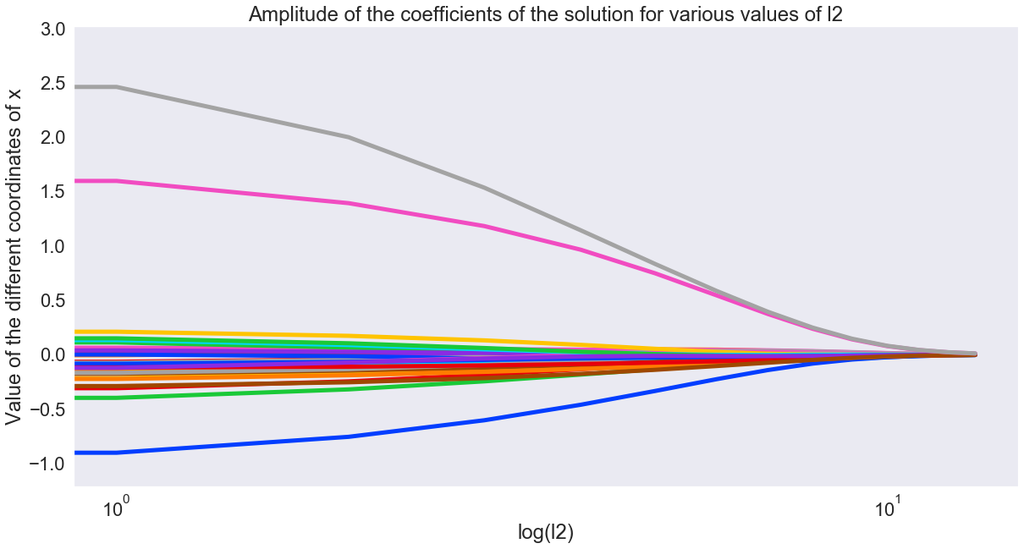

```python
from lib.visuals import l2_regularization_plot

clf = lambda l2: LogisticRegression(solver='gd', l1=0.01, l2=l2, max_iter=1000)

l2_regularization_plot(clf, A_train, b_train)
```

# V. Further development: MEM-SGD

## Introduction.

Inside this section we decided to choose the algorithm `MEM-SGD` presented in [1] and look at its performance for a logistic regression task. The main application for a `MEM-SGD` algorithm is to reduce of the number of communications in distributed computing optimization tasks, but it also provides a good convergence rate, similar to the vanilla `SGD`. Within this section we are not going to consider large-scale time-consuming computations because of the enormous size of such datasets, computational complexity, difficulty to provide the data(~3.6 Gb in the original paper) and to reproduce the result, but we want to analyze the general properties of the algorithm, compare different compression operators and look at the convergence rate in comparison with the vanilla `SGD`.

## `MEM-SGD`.

### Overview.

The general idea of the `MEM-SGD` is to update the approximation vector $x_t$ with the shift in only $k$ directions of $d$(number of coordinates), instead of updating using the whole gradient vector. Additionally, the algorithm keeps the memory vector $m$, which contains the rest $(d-k)$ gradients for all data samples that were chosen previously. Finally, we accumulate a gradient of each position in vector $x$ over all data samples that were chosen before. If the current position in vector $x$ has been chosen for the update the whole accumulated gradient is applied and reset after the step. So, `MEM-SGD` is some kind of mini-batch algorithms, but the size of the batch is random and cannot be predicted.

### Compaction operators.

The important question is how to dfine the compression operator and which positions to consider. Theoretical definition of the compression operator can be found in [1]. In our experiments we are going to use two different compression operators:

1. `rand_k` - operator. The idea is to choose any random $k$ positions of the gradient vector and reset the others.
2. `top_k` - operator. Here the idea is to choose $k$ maximum gradient positions and reset the others.

### Learning rate.

`MEM-SGD` algorithm converges under the set of conditions for the `step_size` and number of iterations of the algorithm. The general result is that the number of steps for each epoch should obey the restriction $T = \Omega(\frac{d}{k}(\frac{L}{\mu})^{1/2})$ and the learning rate is chosen with the equation: $\eta_t = \frac{8}{\mu(t+a)}, a = C\frac{d}{k}$. The constant $C$ is chosen according to the size of the dataset, the recommended value for large-scale datasets($d \approx 2000, n \approx 400000$) is $C = 1-10$, but for small dataset the value should be increased, because it influences the width of the step, for our dataset we have chosen $C = 10000$.

### Epoch result.

The result after each epoch is calculated using the weighted average over all steps within the epoch. $\overline{x}_T = \sum_{0}^{T-1} w_tx_t, w_t = (t+a)^2$.

### Disadvantages.

`MEM-SGD` as an `SGD`- modification inherits a set of `SGD` problems. One of these problems is the problem of dependency on the initial approximation. We have faced this problem using $x_0 = 0$ with `top_k` - compression operator. The algorithm doesn't converge for his approximation, so we have to change the initial approximation to $x_0 = 1$ to get better result. The same change will be done when comparing the `MEM-SGD` and `SGD` algorithms for consistency.

```
def MEM_SGD(x0, grad, max_iter, n, L, mu, configs = None):
    '''
    Parameters
    ----------
    x: array, shape (nb_features,)
        The point to apply the operation to
    k: number of coordinates to consider

    Returns
    -------
    x: array, shape (nb_features,)
        The final contracted view of the point
    '''
    def top_k(x, k):
        n = len(x)
        indices = x.argsort()[-k:][::-1]
        x_out = [x[i] if i in indices else 0 for i in range(0, n)]
        return x_out

    def rand_k(x, k):
        n = len(x)
        indices = random.sample(range(0, n), k)
        x_out = [x[i] if i in indices else 0 for i in range(0, n)]
        return x_out

    COMPRESSION_OPERATOR = {
        'top_k': top_k,
        'rand_k': rand_k
    }

    x0 = x0 + 1 # important step to avoid the bad approx. problem with the top_k comp
    if configs is None:
        raise BaseException("No configuration for the algorithm")

    comp = configs['comp']
    k = int(x0.shape[0] * configs['k'])
    print("Number of coefficients in percents: " + str(configs['k'])+", in samples: " +str(k) + ", total: " + str(x0.shape[0]))
    comp_operator = COMPRESSION_OPERATOR.get(comp, None)

    if comp_operator == None:
        raise BaseException("Invalid Compression Operator")
    x = x0
    x_tab = np.copy(x)
    d = len(x)
    m = np.zeros(x0.shape)
    x_avg = np.zeros(x0.shape)
    w_s = 0
    for t in range(0, max_iter):
        a = 10000*d/k
        step_size = 8/(mu*(t + a))

        i = np.random.randint(0, n)
        gradient = grad(x, i)

        g = comp_operator(m + step_size * gradient, k)

        x = x - g
        m = m + step_size * gradient - g

        w = (t + a)**2
        w_s = w_s + w
        x_avg = x_avg + w * np.copy(x)

        if t%n == 0: # each completed epoch
            x_avg = x_avg / w_s
            x_tab = np.vstack((x_tab, np.copy(x_avg)))
            x_avg = np.zeros(x0.shape)
            w_s = 0

    return x, x_tab
```

## Experiments.

We have conducted a set of experiments to analyze `MEM-SGD`.

1.`MEM-SGD` with `rand_k`-compression operator for different k.

2.`MEM-SGD` with `top_k`-compression operator for different k.

3.Comparison of `rand_k` and `top_k`.

4.Compare `MEM-SGD` with SGD.

For (1.) and (2.) we compare the results of `MEM-SGD` for k = 5%, 10%, 20% and 50% of the whole vector size. Number of iterations was set to $n$ to fulfill the restrictions of the Theorem of convergence(when applying to our data and scales $T = \Omega(n)$ is ok).

### 1. `rand_k` - compression operator.

```python
from lib.linear_model import LogisticRegression
from lib.visuals import learning_curve

epochs = 50
n = len(b_train)

clf_mem_sgd_rand_5 = LogisticRegression(solver='mem_sgd', l2=0.01, max_iter=epochs*n, configs = {'comp':'rand_k', 'k': 0.05})
clf_mem_sgd_rand_10 = LogisticRegression(solver='mem_sgd', l2=0.01, max_iter=epochs*n, configs = {'comp':'rand_k', 'k': 0.1})
clf_mem_sgd_rand_20 = LogisticRegression(solver='mem_sgd', l2=0.01, max_iter=epochs*n, configs = {'comp':'rand_k', 'k': 0.2})
clf_mem_sgd_rand_50 = LogisticRegression(solver='mem_sgd', l2=0.01, max_iter=epochs*n, configs = {'comp':'rand_k', 'k': 0.5})
```

```python
clf_mem_sgd_rand_5.fit(A_train, b_train)
clf_mem_sgd_rand_10.fit(A_train, b_train)
clf_mem_sgd_rand_20.fit(A_train, b_train)
clf_mem_sgd_rand_50.fit(A_train, b_train)
```

```
Number of coefficients in percents: 0.05, in samples: 1, total: 28
Number of coefficients in percents: 0.1, in samples: 2, total: 28
Number of coefficients in percents: 0.2, in samples: 5, total: 28
Number of coefficients in percents: 0.5, in samples: 14, total: 28
```

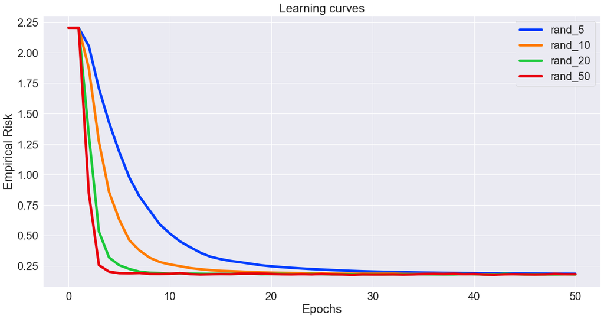

```
mem_sgd_rand_5:
	Accuracy on training set: 94.3%
	Accuracy on testing set:  90.9%
mem_sgd_rand_10:
	Accuracy on training set: 94.6%
	Accuracy on testing set:  90.9%
mem_sgd_rand_20:
	Accuracy on training set: 93.6%
	Accuracy on testing set:  92.9%
mem_sgd_rand_50:
	Accuracy on training set: 93.6%
	Accuracy on testing set:  90.9%
```

```python
learning_curve(rand_5=clf_mem_sgd_rand_5, rand_10=clf_mem_sgd_rand_10,\
               rand_20=clf_mem_sgd_rand_20, rand_50=clf_mem_sgd_rand_50)

for clf, name in zip([clf_mem_sgd_rand_5, clf_mem_sgd_rand_10, clf_mem_sgd_rand_20, clf_mem_sgd_rand_50],
                     ['mem_sgd_rand_5', 'mem_sgd_rand_10', 'mem_sgd_rand_20', 'mem_sgd_rand_50']):
    print(name + ':\n' \
          + "\tAccuracy on training set: {0:0.1f}%".format(100*clf.score(A_train, b_train)))
    print("\tAccuracy on testing set:  {0:0.1f}%".format(100*clf.score(A_test, b_test)))
```

**Conclusion:** We see that the algorithm converges for such compression operator and as more directions(bigger $k$) we use as faster we get the better result.

### 2. `top_k` - compression operator.

```python
from lib.linear_model import LogisticRegression
from lib.visuals import learning_curve

epochs = 50
n = len(b_train)

clf_mem_sgd_top_5 = LogisticRegression(solver='mem_sgd', l2=0.01, max_iter=epochs*n, configs = {'comp':'top_k', 'k': 0.05})
clf_mem_sgd_top_10 = LogisticRegression(solver='mem_sgd', l2=0.01, max_iter=epochs*n, configs = {'comp':'top_k', 'k': 0.1})
clf_mem_sgd_top_20 = LogisticRegression(solver='mem_sgd', l2=0.01, max_iter=epochs*n, configs = {'comp':'top_k', 'k': 0.2})
clf_mem_sgd_top_50 = LogisticRegression(solver='mem_sgd', l2=0.01, max_iter=epochs*n, configs = {'comp':'top_k', 'k': 0.5})
```

```python
clf_mem_sgd_top_5.fit(A_train, b_train)
clf_mem_sgd_top_10.fit(A_train, b_train)
clf_mem_sgd_top_20.fit(A_train, b_train)
clf_mem_sgd_top_50.fit(A_train, b_train)
```

```
Number of coefficients in percents: 0.05, in samples: 1, total: 28
Number of coefficients in percents: 0.1, in samples: 2, total: 28
Number of coefficients in percents: 0.2, in samples: 5, total: 28
Number of coefficients in percents: 0.5, in samples: 14, total: 28
```

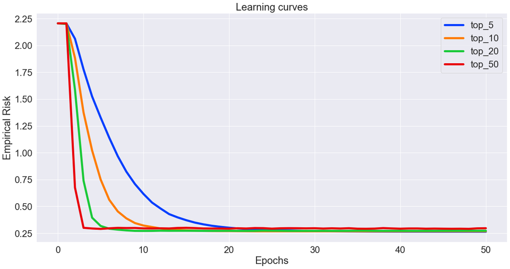

```
mem_sgd_top_5:
	Accuracy on training set: 90.9%
	Accuracy on testing set:  88.9%
mem_sgd_top_10:
	Accuracy on training set: 89.2%
	Accuracy on testing set:  86.9%
mem_sgd_top_20:
	Accuracy on training set: 89.9%
	Accuracy on testing set:  87.9%
mem_sgd_top_50:
	Accuracy on training set: 89.2%
	Accuracy on testing set:  83.8%
```

```python
learning_curve(top_5=clf_mem_sgd_top_5, top_10=clf_mem_sgd_top_10,\
               top_20=clf_mem_sgd_top_20, top_50=clf_mem_sgd_top_50)

for clf, name in zip([clf_mem_sgd_top_5, clf_mem_sgd_top_10, clf_mem_sgd_top_20, clf_mem_sgd_top_50],
                     ['mem_sgd_top_5', 'mem_sgd_top_10','mem_sgd_top_20', 'mem_sgd_top_50']):
    print(name + ':\n' \
          + "\tAccuracy on training set: {0:0.1f}%".format(100*clf.score(A_train, b_train)))
    print("\tAccuracy on testing set:  {0:0.1f}%".format(100*clf.score(A_test, b_test)))
```

### 3.Comparison of `rand_k` and `top_k`.

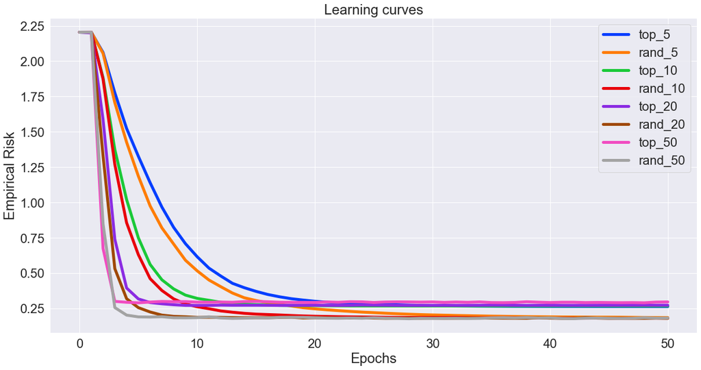

```
mem_sgd_top_5:
	Accuracy on training set: 90.9%
	Accuracy on testing set:  88.9%
mem_sgd_rand_5:
	Accuracy on training set: 94.3%
	Accuracy on testing set:  90.9%
mem_sgd_top_10:
	Accuracy on training set: 89.2%
	Accuracy on testing set:  86.9%
mem_sgd_rand_10:
	Accuracy on training set: 94.6%
	Accuracy on testing set:  90.9%
mem_sgd_top_20:
	Accuracy on training set: 89.9%
	Accuracy on testing set:  87.9%
mem_sgd_rand_20:
	Accuracy on training set: 93.6%
	Accuracy on testing set:  92.9%
mem_sgd_top_50:
	Accuracy on training set: 89.2%
	Accuracy on testing set:  83.8%
mem_sgd_rand_50:
	Accuracy on training set: 93.6%
	Accuracy on testing set:  90.9%
```

```python
learning_curve(top_5=clf_mem_sgd_top_5, rand_5=clf_mem_sgd_rand_5, \
               top_10=clf_mem_sgd_top_10, rand_10=clf_mem_sgd_rand_10, \
               top_20=clf_mem_sgd_top_20, rand_20=clf_mem_sgd_rand_20, \
               top_50=clf_mem_sgd_top_50, rand_50=clf_mem_sgd_rand_50)

for clf, name in zip([clf_mem_sgd_top_5, clf_mem_sgd_rand_5, \
                      clf_mem_sgd_top_10, clf_mem_sgd_rand_10, \
                      clf_mem_sgd_top_20, clf_mem_sgd_rand_20, \
                      clf_mem_sgd_top_50, clf_mem_sgd_rand_50], ['mem_sgd_top_5', 'mem_sgd_rand_5', \
                                                                 'mem_sgd_top_10', 'mem_sgd_rand_10',\
                                                                 'mem_sgd_top_20', 'mem_sgd_rand_20', \
                                                                 'mem_sgd_top_50', 'mem_sgd_rand_50']):
    print(name + ':\n' \
          + "\tAccuracy on training set: {0:0.1f}%".format(100*clf.score(A_train, b_train)))
    print("\tAccuracy on testing set:  {0:0.1f}%".format(100*clf.score(A_test, b_test)))
```

### 4. Compare `MEM-SGD` with `SGD`.

**!** Notice, that according to the bad approximation problem we have changed the initial approximation to $x_0 = 1$ for both `MEM-SGD` and `SGD`, so to reproduce the result edit the approximation for the `SGD`($x_0 = 0$ by default).

As we already get the result for `MEM-SGD`, let's calculate only `SGD` results.

```python
from lib.linear_model import LogisticRegression
from lib.visuals import learning_curve

epochs = 50
n = len(b_train)

clf_sgd  = LogisticRegression(solver='sgd', l2=0.01, max_iter=epochs*n)
clf_sgd.fit(A_train, b_train)
```

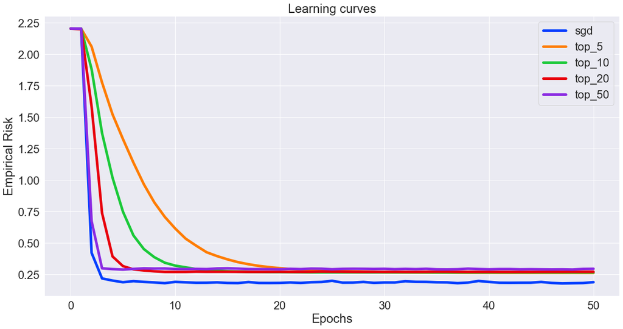

```
sgd:
	Accuracy on training set: 94.6%
	Accuracy on testing set:  92.9%
mem_sgd_top_5:
	Accuracy on training set: 90.9%
	Accuracy on testing set:  88.9%
mem_sgd_top_10:
	Accuracy on training set: 89.2%
	Accuracy on testing set:  86.9%
mem_sgd_top_20:
	Accuracy on training set: 89.9%
	Accuracy on testing set:  87.9%
mem_sgd_top_50:
	Accuracy on training set: 89.2%
	Accuracy on testing set:  83.8%
```

```python
learning_curve(sgd = clf_sgd, top_5=clf_mem_sgd_top_5, top_10=clf_mem_sgd_top_10, \
               top_20=clf_mem_sgd_top_20, top_50=clf_mem_sgd_top_50,)

for clf, name in zip([clf_sgd, clf_mem_sgd_top_5, clf_mem_sgd_top_10, \
                      clf_mem_sgd_top_20, clf_mem_sgd_top_50], ['sgd', 'mem_sgd_top_5',\
                                                                'mem_sgd_top_10', 'mem_sgd_top_20', 'mem_sgd_top_50' ]):
    print(name + ':\n' \
          + "\tAccuracy on training set: {0:0.1f}%".format(100*clf.score(A_train, b_train)))
    print("\tAccuracy on testing set:  {0:0.1f}%".format(100*clf.score(A_test, b_test)))
```

### References

[1] Sebastian U. Stich, Jean-Baptiste Cordonnier, and Martin Jaggi. Sparsified SGD with Memory. arXiv:1809.07599, 2018.